# Orange_Market_Analysis

#### Importing Libraries

```python
import pandas as pd
%pip install seaborn
import seaborn as sns
%pip install matplotlib
import matplotlib.pyplot as plt

%pip install scikit-learn

import pandas as pd
from sklearn.model_selection import train_test_split
from sklearn.ensemble import RandomForestClassifier
from sklearn.metrics import classification_report, accuracy_score, confusion_matrix
from sklearn.preprocessing import LabelEncoder

import matplotlib.pyplot as plt
import seaborn as sns
from sklearn.metrics import confusion_matrix

from sklearn.linear_model import LogisticRegression
from sklearn.tree import DecisionTreeClassifier
from sklearn.ensemble import GradientBoostingClassifier
from sklearn.ensemble import AdaBoostClassifier




import warnings
warnings.filterwarnings('ignore')
```

### Importing Data

```python
train_data = pd.read_csv('churn-bigml-80.csv')
```

### Exploratory Data Analysis

```python
train_data.info()
```

```
<class 'pandas.core.frame.DataFrame'>
RangeIndex: 2666 entries, 0 to 2665
Data columns (total 20 columns):
 #   Column                  Non-Null Count  Dtype
---  ------                  --------------  -----
 0   State                   2666 non-null   object
 1   Account length          2666 non-null   int64
 2   Area code               2666 non-null   int64
 3   International plan      2666 non-null   object
 4   Voice mail plan         2666 non-null   object
 5   Number vmail messages   2666 non-null   int64
 6   Total day minutes       2666 non-null   float64
 7   Total day calls         2666 non-null   int64
 8   Total day charge        2666 non-null   float64
 9   Total eve minutes       2666 non-null   float64
 10  Total eve calls         2666 non-null   int64
 11  Total eve charge        2666 non-null   float64
 12  Total night minutes     2666 non-null   float64
 13  Total night calls       2666 non-null   int64
 14  Total night charge      2666 non-null   float64
 15  Total intl minutes      2666 non-null   float64
 16  Total intl calls        2666 non-null   int64
 17  Total intl charge       2666 non-null   float64
 18  Customer service calls  2666 non-null   int64
 19  Churn                   2666 non-null   bool
dtypes: bool(1), float64(8), int64(8), object(3)
memory usage: 398.5+ KB
```

```python
test_data = pd.read_csv('churn-bigml-20.csv')
test_data.info()
```

```
<class 'pandas.core.frame.DataFrame'>
RangeIndex: 667 entries, 0 to 666
Data columns (total 20 columns):
 #   Column                  Non-Null Count  Dtype
---  ------                  --------------  -----
 0   State                   667 non-null    object
 1   Account length          667 non-null    int64
 2   Area code               667 non-null    int64
 3   International plan      667 non-null    object
 4   Voice mail plan         667 non-null    object
 5   Number vmail messages   667 non-null    int64
 6   Total day minutes       667 non-null    float64
 7   Total day calls         667 non-null    int64
 8   Total day charge        667 non-null    float64
 9   Total eve minutes       667 non-null    float64
 10  Total eve calls         667 non-null    int64
 11  Total eve charge        667 non-null    float64
 12  Total night minutes     667 non-null    float64
 13  Total night calls       667 non-null    int64
 14  Total night charge      667 non-null    float64
 15  Total intl minutes      667 non-null    float64
 16  Total intl calls        667 non-null    int64
 17  Total intl charge       667 non-null    float64
 18  Customer service calls  667 non-null    int64
 19  Churn                   667 non-null    bool
dtypes: bool(1), float64(8), int64(8), object(3)
memory usage: 99.8+ KB
```

#### Merging data

```python
merged_data = pd.concat([train_data, test_data], axis=0)

merged_data.reset_index(drop = True, inplace = True)
merged_data
```

|  | State | Account length | Area code | International plan | Voice mail plan | Number vmail messages | Total day minutes | Total day calls | Total day charge | Total eve minutes | Total eve calls | Total eve charge | Total night minutes | Total night calls | Total night charge | Total intl minutes | Total intl calls | Total intl charge | Customer service calls | Churn |
| --- | --- | --- | --- | --- | --- | --- | --- | --- | --- | --- | --- | --- | --- | --- | --- | --- | --- | --- | --- | --- |
| 0 | KS | 128 | 415 | No | Yes | 25 | 265.1 | 110 | 45.07 | 197.4 | 99 | 16.78 | 244.7 | 91 | 11.01 | 10.0 | 3 | 2.70 | 1 | False |
| 1 | OH | 107 | 415 | No | Yes | 26 | 161.6 | 123 | 27.47 | 195.5 | 103 | 16.62 | 254.4 | 103 | 11.45 | 13.7 | 3 | 3.70 | 1 | False |
| 2 | NJ | 137 | 415 | No | No | 0 | 243.4 | 114 | 41.38 | 121.2 | 110 | 10.30 | 162.6 | 104 | 7.32 | 12.2 | 5 | 3.29 | 0 | False |
| 3 | OH | 84 | 408 | Yes | No | 0 | 299.4 | 71 | 50.90 | 61.9 | 88 | 5.26 | 196.9 | 89 | 8.86 | 6.6 | 7 | 1.78 | 2 | False |
| 4 | OK | 75 | 415 | Yes | No | 0 | 166.7 | 113 | 28.34 | 148.3 | 122 | 12.61 | 186.9 | 121 | 8.41 | 10.1 | 3 | 2.73 | 3 | False |
| ... | ... | ... | ... | ... | ... | ... | ... | ... | ... | ... | ... | ... | ... | ... | ... | ... | ... | ... | ... | ... |
| 3328 | WI | 114 | 415 | No | Yes | 26 | 137.1 | 88 | 23.31 | 155.7 | 125 | 13.23 | 247.6 | 94 | 11.14 | 11.5 | 7 | 3.11 | 2 | False |
| 3329 | AL | 106 | 408 | No | Yes | 29 | 83.6 | 131 | 14.21 | 203.9 | 131 | 17.33 | 229.5 | 73 | 10.33 | 8.1 | 3 | 2.19 | 1 | False |
| 3330 | VT | 60 | 415 | No | No | 0 | 193.9 | 118 | 32.96 | 85.0 | 110 | 7.23 | 210.1 | 134 | 9.45 | 13.2 | 8 | 3.56 | 3 | False |
| 3331 | WV | 159 | 415 | No | No | 0 | 169.8 | 114 | 28.87 | 197.7 | 105 | 16.80 | 193.7 | 82 | 8.72 | 11.6 | 4 | 3.13 | 1 | False |
| 3332 | CT | 184 | 510 | Yes | No | 0 | 213.8 | 105 | 36.35 | 159.6 | 84 | 13.57 | 139.2 | 137 | 6.26 | 5.0 | 10 | 1.35 | 2 | False |

3333 rows × 20 columns

```python
merged_data.describe()
```

|  | Account length | Area code | Number vmail messages | Total day minutes | Total day calls | Total day charge | Total eve minutes | Total eve calls | Total eve charge | Total night minutes | Total night calls | Total night charge | Total intl minutes | Total intl calls | Total intl charge | Customer service calls |
| --- | --- | --- | --- | --- | --- | --- | --- | --- | --- | --- | --- | --- | --- | --- | --- | --- |
| count | 3333.000000 | 3333.000000 | 3333.000000 | 3333.000000 | 3333.000000 | 3333.000000 | 3333.000000 | 3333.000000 | 3333.000000 | 3333.000000 | 3333.000000 | 3333.000000 | 3333.000000 | 3333.000000 | 3333.000000 | 3333.000000 |
| mean | 101.064806 | 437.182418 | 8.099010 | 179.775098 | 100.435644 | 30.562307 | 200.980348 | 100.114311 | 17.083540 | 200.872037 | 100.107711 | 9.039325 | 10.237294 | 4.479448 | 2.764581 | 1.562856 |
| std | 39.822106 | 42.371290 | 13.688365 | 54.467389 | 20.069084 | 9.259435 | 50.713844 | 19.922625 | 4.310668 | 50.573847 | 19.568609 | 2.275873 | 2.791840 | 2.461214 | 0.753773 | 1.315491 |
| min | 1.000000 | 408.000000 | 0.000000 | 0.000000 | 0.000000 | 0.000000 | 0.000000 | 0.000000 | 0.000000 | 23.200000 | 33.000000 | 1.040000 | 0.000000 | 0.000000 | 0.000000 | 0.000000 |
| 25% | 74.000000 | 408.000000 | 0.000000 | 143.700000 | 87.000000 | 24.430000 | 166.600000 | 87.000000 | 14.160000 | 167.000000 | 87.000000 | 7.520000 | 8.500000 | 3.000000 | 2.300000 | 1.000000 |
| 50% | 101.000000 | 415.000000 | 0.000000 | 179.400000 | 101.000000 | 30.500000 | 201.400000 | 100.000000 | 17.120000 | 201.200000 | 100.000000 | 9.050000 | 10.300000 | 4.000000 | 2.780000 | 1.000000 |
| 75% | 127.000000 | 510.000000 | 20.000000 | 216.400000 | 114.000000 | 36.790000 | 235.300000 | 114.000000 | 20.000000 | 235.300000 | 113.000000 | 10.590000 | 12.100000 | 6.000000 | 3.270000 | 2.000000 |
| max | 243.000000 | 510.000000 | 51.000000 | 350.800000 | 165.000000 | 59.640000 | 363.700000 | 170.000000 | 30.910000 | 395.000000 | 175.000000 | 17.770000 | 20.000000 | 20.000000 | 5.400000 | 9.000000 |

```python
merged_data["Customer ID"] = [i for i in range(merged_data.shape[0])]
```

```python
merged_data = merged_data[["Customer ID"] + merged_data.columns.to_list()[:-1]]
merged_data
```

|  | Customer ID | State | Account length | Area code | International plan | Voice mail plan | Number vmail messages | Total day minutes | Total day calls | Total day charge | ... | Total eve calls | Total eve charge | Total night minutes | Total night calls | Total night charge | Total intl minutes | Total intl calls | Total intl charge | Customer service calls | Churn |
| --- | --- | --- | --- | --- | --- | --- | --- | --- | --- | --- | --- | --- | --- | --- | --- | --- | --- | --- | --- | --- | --- |
| 0 | 0 | KS | 128 | 415 | No | Yes | 25 | 265.1 | 110 | 45.07 | ... | 99 | 16.78 | 244.7 | 91 | 11.01 | 10.0 | 3 | 2.70 | 1 | False |
| 1 | 1 | OH | 107 | 415 | No | Yes | 26 | 161.6 | 123 | 27.47 | ... | 103 | 16.62 | 254.4 | 103 | 11.45 | 13.7 | 3 | 3.70 | 1 | False |
| 2 | 2 | NJ | 137 | 415 | No | No | 0 | 243.4 | 114 | 41.38 | ... | 110 | 10.30 | 162.6 | 104 | 7.32 | 12.2 | 5 | 3.29 | 0 | False |
| 3 | 3 | OH | 84 | 408 | Yes | No | 0 | 299.4 | 71 | 50.90 | ... | 88 | 5.26 | 196.9 | 89 | 8.86 | 6.6 | 7 | 1.78 | 2 | False |
| 4 | 4 | OK | 75 | 415 | Yes | No | 0 | 166.7 | 113 | 28.34 | ... | 122 | 12.61 | 186.9 | 121 | 8.41 | 10.1 | 3 | 2.73 | 3 | False |
| ... | ... | ... | ... | ... | ... | ... | ... | ... | ... | ... | ... | ... | ... | ... | ... | ... | ... | ... | ... | ... | ... |
| 3328 | 3328 | WI | 114 | 415 | No | Yes | 26 | 137.1 | 88 | 23.31 | ... | 125 | 13.23 | 247.6 | 94 | 11.14 | 11.5 | 7 | 3.11 | 2 | False |
| 3329 | 3329 | AL | 106 | 408 | No | Yes | 29 | 83.6 | 131 | 14.21 | ... | 131 | 17.33 | 229.5 | 73 | 10.33 | 8.1 | 3 | 2.19 | 1 | False |
| 3330 | 3330 | VT | 60 | 415 | No | No | 0 | 193.9 | 118 | 32.96 | ... | 110 | 7.23 | 210.1 | 134 | 9.45 | 13.2 | 8 | 3.56 | 3 | False |
| 3331 | 3331 | WV | 159 | 415 | No | No | 0 | 169.8 | 114 | 28.87 | ... | 105 | 16.80 | 193.7 | 82 | 8.72 | 11.6 | 4 | 3.13 | 1 | False |
| 3332 | 3332 | CT | 184 | 510 | Yes | No | 0 | 213.8 | 105 | 36.35 | ... | 84 | 13.57 | 139.2 | 137 | 6.26 | 5.0 | 10 | 1.35 | 2 | False |

3333 rows × 21 columns

```python
train_data.shape[0]+test_data.shape[0]
```

```
3333
```

```python
merged_data.to_csv("orange_data.csv")
```

```python
merged_data.shape[0]
```

```
3333
```

```python
#percentage of missing values

round(merged_data.isnull().sum()/merged_data.shape[0] * 100, 2)
```

```
Customer ID               0.0
State                     0.0
Account length            0.0
Area code                 0.0
International plan        0.0
Voice mail plan           0.0
Number vmail messages     0.0
Total day minutes         0.0
Total day calls           0.0
Total day charge          0.0
Total eve minutes         0.0
Total eve calls           0.0
Total eve charge          0.0
Total night minutes       0.0
Total night calls         0.0
Total night charge        0.0
Total intl minutes        0.0
Total intl calls          0.0
Total intl charge         0.0
Customer service calls    0.0
Churn                     0.0
dtype: float64
```

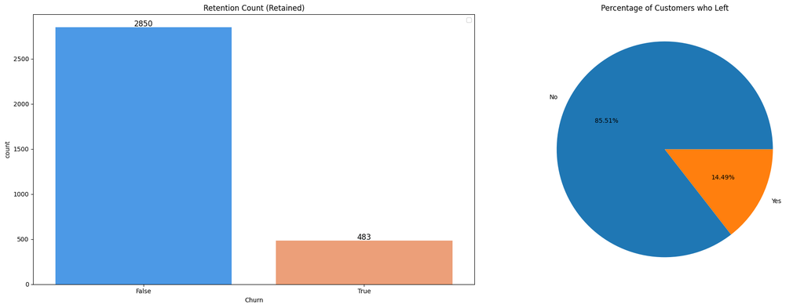

```python
# to create  figure with 2 subplots (1 row, 2 columns)
plt.figure(figsize=(20, 7))

# Plot 1: For data_retained
plt.subplot(1, 2, 1)  # 1 row, 2 columns, first subplot
ax= sns.countplot(x='Churn', data=merged_data, palette=["#3399FF", "#FF9966"])
#  to add values on top of the bars
for p in ax.patches:
    ax.annotate(f'{int(p.get_height())}',
                (p.get_x() + p.get_width() / 2., p.get_height()),  # Position
                ha='center', va='center', fontsize=12, color='black', xytext=(0, 5), textcoords='offset points')
plt.title('Retention Count (Retained)')


plt.subplot(1, 2, 2)
percent_count = merged_data['Churn'].value_counts(normalize = True)
plt.pie(x = merged_data['Churn'].value_counts(),labels = ["No", "Yes"], autopct = lambda percent_count: '{:.2f}%'.format(percent_count))
plt.title('Percentage of Customers who Left', fontsize = 12)
ax.legend()
plt.tight_layout()
plt.show()
```

###### Customer Retention: A significant majority of customers (85.51%) are retained, while only 14.49% have churned, as illustrated in the pie chart.

###### Retention Count: The bar chart highlights that 2,850 customers stayed with the company, compared to 483 who left.

###### Class Imbalance: The dataset has a notable imbalance in churn status, with retained customers dominating, which is important to consider for model development and evaluation

```python
merged_data["Churn"].unique()
```

```
array([False,  True])
```

```python
data_retained = merged_data[merged_data["Churn"]==False]
data_churned = merged_data[merged_data['Churn']==True]
```

```python
data_retained
```

|  | Customer ID | State | Account length | Area code | International plan | Voice mail plan | Number vmail messages | Total day minutes | Total day calls | Total day charge | ... | Total eve calls | Total eve charge | Total night minutes | Total night calls | Total night charge | Total intl minutes | Total intl calls | Total intl charge | Customer service calls | Churn |
| --- | --- | --- | --- | --- | --- | --- | --- | --- | --- | --- | --- | --- | --- | --- | --- | --- | --- | --- | --- | --- | --- |
| 0 | 0 | KS | 128 | 415 | No | Yes | 25 | 265.1 | 110 | 45.07 | ... | 99 | 16.78 | 244.7 | 91 | 11.01 | 10.0 | 3 | 2.70 | 1 | False |
| 1 | 1 | OH | 107 | 415 | No | Yes | 26 | 161.6 | 123 | 27.47 | ... | 103 | 16.62 | 254.4 | 103 | 11.45 | 13.7 | 3 | 3.70 | 1 | False |
| 2 | 2 | NJ | 137 | 415 | No | No | 0 | 243.4 | 114 | 41.38 | ... | 110 | 10.30 | 162.6 | 104 | 7.32 | 12.2 | 5 | 3.29 | 0 | False |
| 3 | 3 | OH | 84 | 408 | Yes | No | 0 | 299.4 | 71 | 50.90 | ... | 88 | 5.26 | 196.9 | 89 | 8.86 | 6.6 | 7 | 1.78 | 2 | False |
| 4 | 4 | OK | 75 | 415 | Yes | No | 0 | 166.7 | 113 | 28.34 | ... | 122 | 12.61 | 186.9 | 121 | 8.41 | 10.1 | 3 | 2.73 | 3 | False |
| ... | ... | ... | ... | ... | ... | ... | ... | ... | ... | ... | ... | ... | ... | ... | ... | ... | ... | ... | ... | ... | ... |
| 3328 | 3328 | WI | 114 | 415 | No | Yes | 26 | 137.1 | 88 | 23.31 | ... | 125 | 13.23 | 247.6 | 94 | 11.14 | 11.5 | 7 | 3.11 | 2 | False |
| 3329 | 3329 | AL | 106 | 408 | No | Yes | 29 | 83.6 | 131 | 14.21 | ... | 131 | 17.33 | 229.5 | 73 | 10.33 | 8.1 | 3 | 2.19 | 1 | False |
| 3330 | 3330 | VT | 60 | 415 | No | No | 0 | 193.9 | 118 | 32.96 | ... | 110 | 7.23 | 210.1 | 134 | 9.45 | 13.2 | 8 | 3.56 | 3 | False |
| 3331 | 3331 | WV | 159 | 415 | No | No | 0 | 169.8 | 114 | 28.87 | ... | 105 | 16.80 | 193.7 | 82 | 8.72 | 11.6 | 4 | 3.13 | 1 | False |
| 3332 | 3332 | CT | 184 | 510 | Yes | No | 0 | 213.8 | 105 | 36.35 | ... | 84 | 13.57 | 139.2 | 137 | 6.26 | 5.0 | 10 | 1.35 | 2 | False |

2850 rows × 21 columns

```python
data_churned
```

|  | Customer ID | State | Account length | Area code | International plan | Voice mail plan | Number vmail messages | Total day minutes | Total day calls | Total day charge | ... | Total eve calls | Total eve charge | Total night minutes | Total night calls | Total night charge | Total intl minutes | Total intl calls | Total intl charge | Customer service calls | Churn |
| --- | --- | --- | --- | --- | --- | --- | --- | --- | --- | --- | --- | --- | --- | --- | --- | --- | --- | --- | --- | --- | --- |
| 18 | 18 | CO | 77 | 408 | No | No | 0 | 62.4 | 89 | 10.61 | ... | 121 | 14.44 | 209.6 | 64 | 9.43 | 5.7 | 6 | 1.54 | 5 | True |
| 28 | 28 | AZ | 12 | 408 | No | No | 0 | 249.6 | 118 | 42.43 | ... | 119 | 21.45 | 280.2 | 90 | 12.61 | 11.8 | 3 | 3.19 | 1 | True |
| 35 | 35 | MD | 135 | 408 | Yes | Yes | 41 | 173.1 | 85 | 29.43 | ... | 107 | 17.33 | 122.2 | 78 | 5.50 | 14.6 | 15 | 3.94 | 0 | True |
| 45 | 45 | WY | 87 | 415 | No | No | 0 | 151.0 | 83 | 25.67 | ... | 116 | 18.67 | 203.9 | 127 | 9.18 | 9.7 | 3 | 2.62 | 5 | True |
| 48 | 48 | CO | 121 | 408 | No | Yes | 30 | 198.4 | 129 | 33.73 | ... | 77 | 6.40 | 181.2 | 77 | 8.15 | 5.8 | 3 | 1.57 | 3 | True |
| ... | ... | ... | ... | ... | ... | ... | ... | ... | ... | ... | ... | ... | ... | ... | ... | ... | ... | ... | ... | ... | ... |
| 3272 | 3272 | CO | 130 | 408 | No | No | 0 | 271.8 | 129 | 46.21 | ... | 128 | 20.16 | 210.1 | 91 | 9.45 | 8.7 | 2 | 2.35 | 4 | True |
| 3281 | 3281 | MT | 100 | 415 | No | No | 0 | 113.3 | 96 | 19.26 | ... | 89 | 16.82 | 284.5 | 93 | 12.80 | 11.7 | 2 | 3.16 | 4 | True |
| 3318 | 3318 | WA | 84 | 415 | No | No | 0 | 289.1 | 100 | 49.15 | ... | 97 | 19.87 | 223.5 | 148 | 10.06 | 12.7 | 2 | 3.43 | 2 | True |
| 3319 | 3319 | MD | 133 | 510 | No | No | 0 | 295.0 | 141 | 50.15 | ... | 101 | 19.01 | 229.4 | 109 | 10.32 | 12.9 | 4 | 3.48 | 2 | True |
| 3327 | 3327 | CA | 84 | 415 | No | No | 0 | 280.0 | 113 | 47.60 | ... | 90 | 17.19 | 156.8 | 103 | 7.06 | 10.4 | 4 | 2.81 | 0 | True |

483 rows × 21 columns

# Histplot of variables

```python
numeric_data = pd.DataFrame()


for column in merged_data.columns:

    if merged_data[column].dtypes == "int64" or merged_data[column].dtypes == "float64":
        numeric_data[column] = merged_data[column]
```

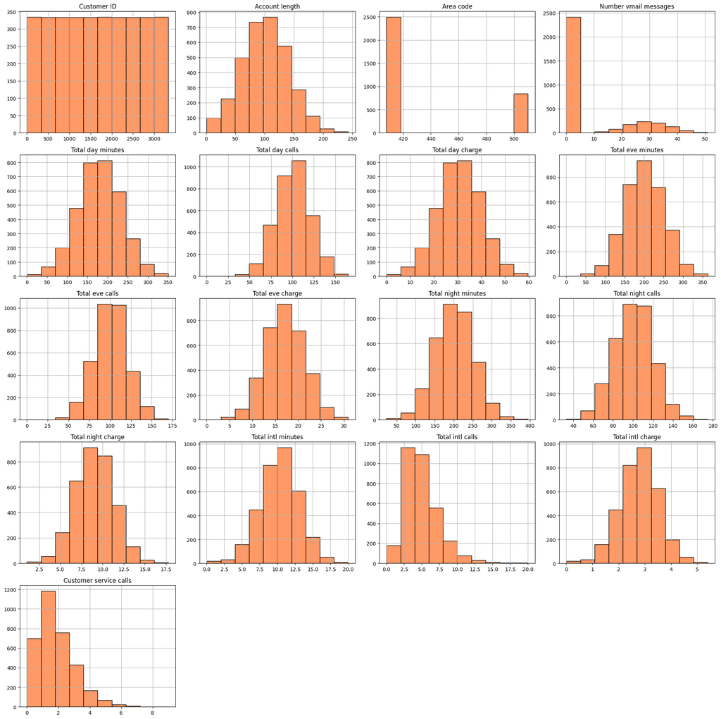

```python
numeric_data.hist(figsize=(20, 20), bins=10, color='#FF9966', edgecolor='black')
plt.tight_layout()
plt.show()
```

# Retained VS Churned

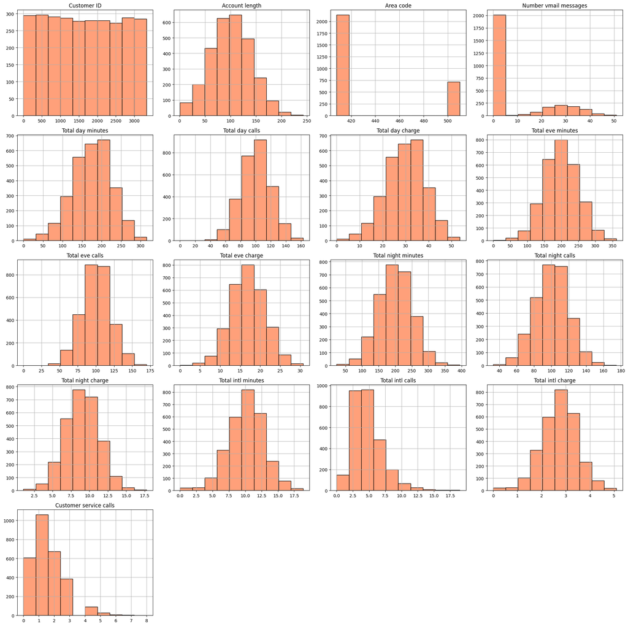

```python
numeric_data_retained= pd.DataFrame()

for column in data_retained.columns:

    if data_retained[column].dtypes == "int64" or data_retained[column].dtypes == "float64":
        numeric_data_retained[column] = data_retained[column]

numeric_data_retained.hist(figsize=(20, 20), bins=10, color="#FFA07A", edgecolor='black')
plt.tight_layout()
plt.show()
```

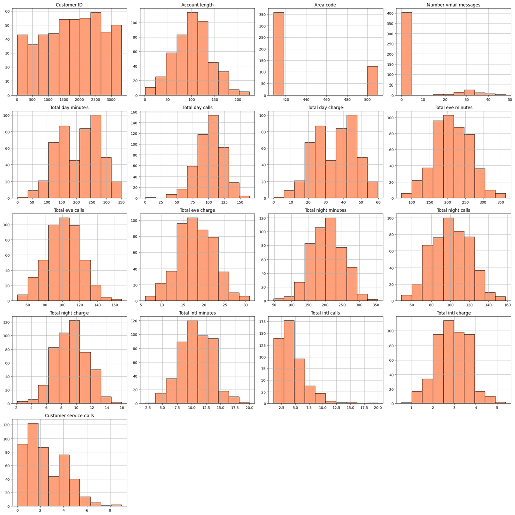

```python
numeric_data_churned= pd.DataFrame()

for column in data_churned.columns:

    if data_churned[column].dtypes == "int64" or data_churned[column].dtypes == "float64":
        numeric_data_churned[column] = data_churned[column]

numeric_data_churned.hist(figsize=(20, 20), bins=10, color="#FFA07A", edgecolor='black')
plt.tight_layout()
plt.show()
```

###### Customer Service Calls:

###### In the churned dataset, there is a noticeable shift toward higher values for customer service calls compared to the retained dataset. This suggests that customers who churn tend to contact customer service more frequently, possibly indicating dissatisfaction or unresolved issues.

###### Voicemail Usage:

###### The churned dataset shows fewer customers with high numbers of voicemail messages compared to the retained dataset. This may indicate that churned customers are less likely to use voicemail services actively.

###### Day Minutes and Charges:

###### Churned customers exhibit slightly higher values for total day minutes and charges compared to retained customers. This suggests that heavy daytime users may be more prone to churn, possibly due to cost-related dissatisfaction.

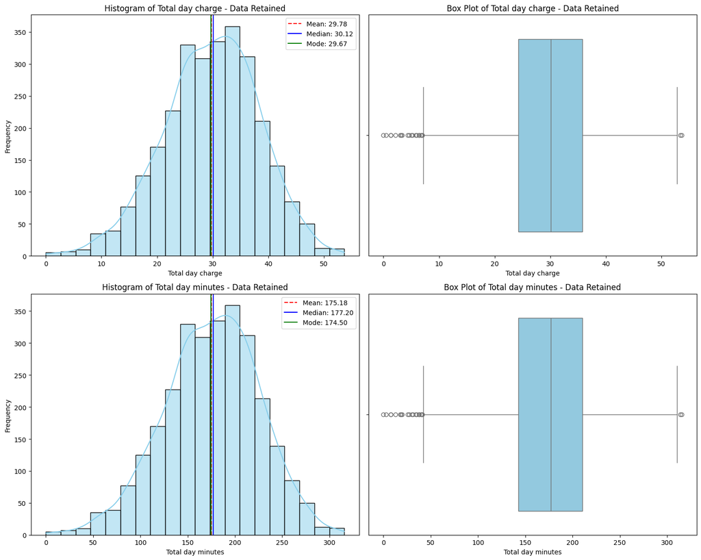

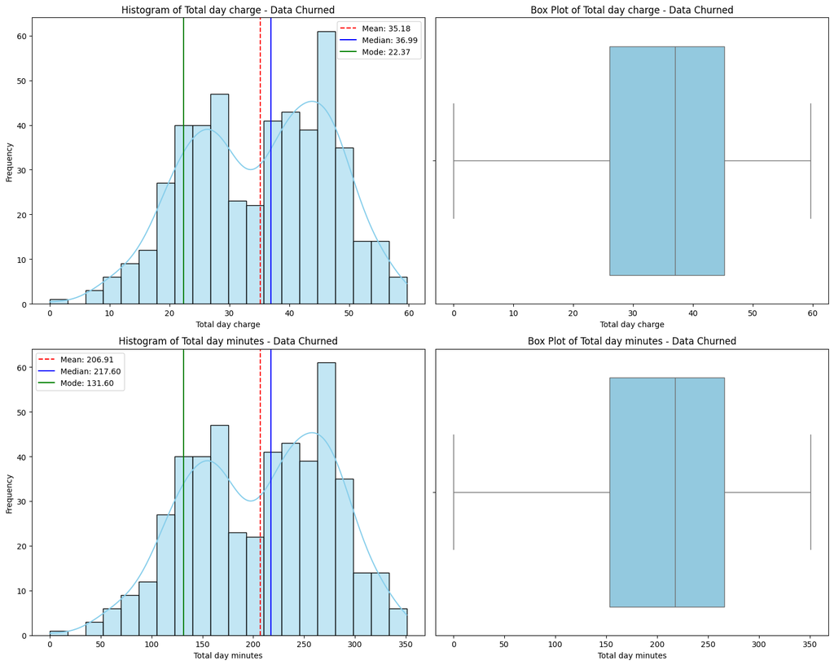

```python
def plot_hist_box(data, column, ax1, ax2, title):
    sns.histplot(data[column], bins=20, kde=True, color='skyblue', ax=ax1)
    mean = data[column].mean()
    median = data[column].median()
    mode = data[column].mode()[0]
    ax1.axvline(mean, color='red', linestyle='--', label=f'Mean: {mean:.2f}')
    ax1.axvline(median, color='blue', linestyle='-', label=f'Median: {median:.2f}')
    ax1.axvline(mode, color='green', linestyle='-', label=f'Mode: {mode:.2f}')
    ax1.set_title(f'Histogram of {column} - {title}')
    ax1.set_xlabel(column)
    ax1.set_ylabel('Frequency')
    ax1.legend()


    sns.boxplot(data=data, x=column, color='skyblue', ax=ax2)
    ax2.set_title(f'Box Plot of {column} - {title}')
    ax2.set_xlabel(column)


fig, axes = plt.subplots(2, 2, figsize=(15, 12))


plot_hist_box(data_retained, 'Total day charge', axes[0, 0], axes[0, 1], 'Data Retained')
plot_hist_box(data_retained, 'Total day minutes', axes[1, 0], axes[1, 1], 'Data Retained')


plt.tight_layout()
plt.show()

#  to reate subplots for 'Total day charge' and 'Total day minutes' for churned data
fig, axes = plt.subplots(2, 2, figsize=(15, 12))

# Plot for 'Total day charge' and 'Total day minutes' for churned data
plot_hist_box(data_churned, 'Total day charge', axes[0, 0], axes[0, 1], 'Data Churned')
plot_hist_box(data_churned, 'Total day minutes', axes[1, 0], axes[1, 1], 'Data Churned')

# to adjust layout for the second set of plots
plt.tight_layout()
plt.show()
```

###### Churned customers have a wider spread in both charges and minutes, as reflected in their box plots, suggesting greater diversity in their usage patterns.

###### High Charges Are a Strong Indicator of Churn:

###### The higher median and mean total day charges for churned customers imply that customers who incur larger bills are at greater risk of leaving.

```python
merged_data.info()
```

```
<class 'pandas.core.frame.DataFrame'>
RangeIndex: 3333 entries, 0 to 3332
Data columns (total 21 columns):
 #   Column                  Non-Null Count  Dtype
---  ------                  --------------  -----
 0   Customer ID             3333 non-null   int64
 1   State                   3333 non-null   object
 2   Account length          3333 non-null   int64
 3   Area code               3333 non-null   int64
 4   International plan      3333 non-null   object
 5   Voice mail plan         3333 non-null   object
 6   Number vmail messages   3333 non-null   int64
 7   Total day minutes       3333 non-null   float64
 8   Total day calls         3333 non-null   int64
 9   Total day charge        3333 non-null   float64
 10  Total eve minutes       3333 non-null   float64
 11  Total eve calls         3333 non-null   int64
 12  Total eve charge        3333 non-null   float64
 13  Total night minutes     3333 non-null   float64
 14  Total night calls       3333 non-null   int64
 15  Total night charge      3333 non-null   float64
 16  Total intl minutes      3333 non-null   float64
 17  Total intl calls        3333 non-null   int64
 18  Total intl charge       3333 non-null   float64
 19  Customer service calls  3333 non-null   int64
 20  Churn                   3333 non-null   bool
dtypes: bool(1), float64(8), int64(9), object(3)
memory usage: 524.2+ KB
```

# Segmentation

```python
#Segmented using Account Length
min(merged_data["Account length"]) , max(merged_data["Account length"])
```

```
(1, 243)
```

```python
Customer_account_segmented=pd.DataFrame(merged_data)
# Define the bins and labels for segmentation
bins = [0, 50, 100, 150, 244]  # Adjust based on your range and domain knowledge
labels = ["New Customers", "Mid-Tenure Customers", "Established Customers", "Loyal Customers"]

data_retained.loc[:, 'Customer_segment_account'] = pd.cut(data_retained['Account length'], bins=bins, labels=labels, right=False)
data_churned.loc[:, 'Customer_segment_account'] = pd.cut(data_churned['Account length'], bins=bins, labels=labels, right=False)
Customer_account_segmented.loc[:, 'Customer_segment_account'] = pd.cut(merged_data['Account length'], bins=bins, labels=labels, right=False)


data_retained
Customer_account_segmented.info()
```

```
<class 'pandas.core.frame.DataFrame'>
RangeIndex: 3333 entries, 0 to 3332
Data columns (total 22 columns):
 #   Column                    Non-Null Count  Dtype
---  ------                    --------------  -----
 0   Customer ID               3333 non-null   int64
 1   State                     3333 non-null   object
 2   Account length            3333 non-null   int64
 3   Area code                 3333 non-null   int64
 4   International plan        3333 non-null   object
 5   Voice mail plan           3333 non-null   object
 6   Number vmail messages     3333 non-null   int64
 7   Total day minutes         3333 non-null   float64
 8   Total day calls           3333 non-null   int64
 9   Total day charge          3333 non-null   float64
 10  Total eve minutes         3333 non-null   float64
 11  Total eve calls           3333 non-null   int64
 12  Total eve charge          3333 non-null   float64
 13  Total night minutes       3333 non-null   float64
 14  Total night calls         3333 non-null   int64
 15  Total night charge        3333 non-null   float64
 16  Total intl minutes        3333 non-null   float64
 17  Total intl calls          3333 non-null   int64
 18  Total intl charge         3333 non-null   float64
 19  Customer service calls    3333 non-null   int64
 20  Churn                     3333 non-null   bool
 21  Customer_segment_account  3333 non-null   category
dtypes: bool(1), category(1), float64(8), int64(9), object(3)
memory usage: 527.6+ KB
```

```python
Customer_account_segmented['Customer_segment_account'].unique()
```

```
['Established Customers', 'Mid-Tenure Customers', 'Loyal Customers', 'New Customers']
Categories (4, object): ['New Customers' < 'Mid-Tenure Customers' < 'Established Customers' < 'Loyal Customers']
```

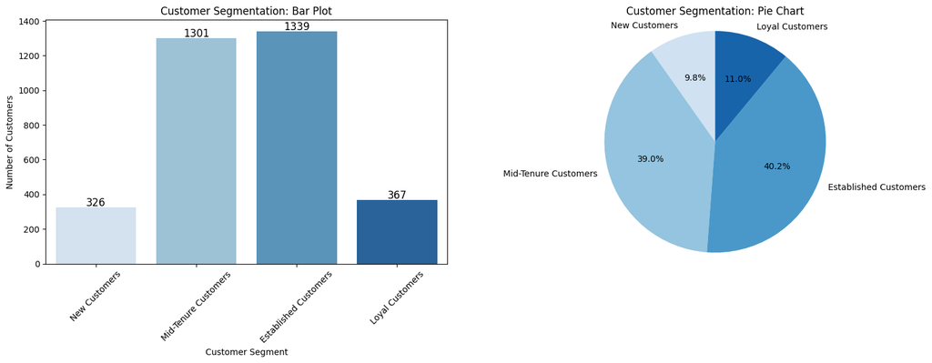

```python
# Count the values for each segment
segment_counts = Customer_account_segmented['Customer_segment_account'].value_counts().reindex(
    ['New Customers', 'Mid-Tenure Customers', 'Established Customers', 'Loyal Customers']
)


# Bar plot
plt.figure(figsize=(16, 6))
plt.subplot(1, 2, 1)
ax = sns.barplot(x=segment_counts.index, y=segment_counts.values, palette='Blues')
for p in ax.patches:
    ax.annotate(f'{int(p.get_height())}',  # The value on the bar
                (p.get_x() + p.get_width() / 2., p.get_height()),  # Position
                ha='center', va='center', fontsize=12, color='black', xytext=(0, 5), textcoords='offset points')
plt.title('Customer Segmentation: Bar Plot')
plt.xlabel('Customer Segment')
plt.ylabel('Number of Customers')
plt.xticks(rotation=45)


plt.subplot(1, 2, 2)
plt.pie(segment_counts, labels=segment_counts.index, autopct='%1.1f%%', startangle=90, colors=sns.color_palette('Blues', n_colors=4))
plt.title('Customer Segmentation: Pie Chart')
plt.axis('equal')  # Ensures pie chart is circular
plt.tight_layout()
plt.show()
```

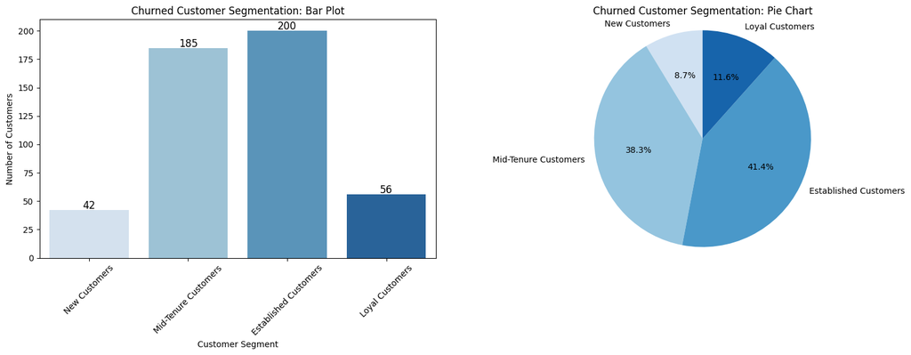

```python
# Count the values for each segment
segment_counts = data_churned['Customer_segment_account'].value_counts().reindex(
    ['New Customers', 'Mid-Tenure Customers', 'Established Customers', 'Loyal Customers']
)


# Bar plot
plt.figure(figsize=(16, 6))
plt.subplot(1, 2, 1)
ax = sns.barplot(x=segment_counts.index, y=segment_counts.values, palette='Blues')
for p in ax.patches:
    ax.annotate(f'{int(p.get_height())}',  # The value on the bar
                (p.get_x() + p.get_width() / 2., p.get_height()),  # Position
                ha='center', va='center', fontsize=12, color='black', xytext=(0, 5), textcoords='offset points')
plt.title('Churned Customer Segmentation: Bar Plot')
plt.xlabel('Customer Segment')
plt.ylabel('Number of Customers')
plt.xticks(rotation=45)


plt.subplot(1, 2, 2)
plt.pie(segment_counts, labels=segment_counts.index, autopct='%1.1f%%', startangle=90, colors=sns.color_palette('Blues', n_colors=4))
plt.title('Churned Customer Segmentation: Pie Chart')
plt.axis('equal')  # Ensures pie chart is circular
plt.tight_layout()
plt.show()
```

##### New Customers Have Smaller but Significant Churn: Although New Customers contribute only 42 churned customers (8.7%), addressing their early experience could further reduce churn.

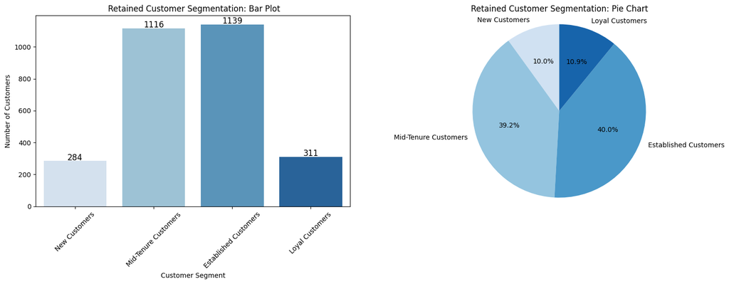

```python
# Count the values for each segment
segment_counts = data_retained['Customer_segment_account'].value_counts().reindex(
    ['New Customers', 'Mid-Tenure Customers', 'Established Customers', 'Loyal Customers']
)


# Bar plot
plt.figure(figsize=(16, 6))
plt.subplot(1, 2, 1)
ax = sns.barplot(x=segment_counts.index, y=segment_counts.values, palette='Blues')
for p in ax.patches:
    ax.annotate(f'{int(p.get_height())}',  # The value on the bar
                (p.get_x() + p.get_width() / 2., p.get_height()),  # Position
                ha='center', va='center', fontsize=12, color='black', xytext=(0, 5), textcoords='offset points')
plt.title(' Retained Customer Segmentation: Bar Plot')
plt.xlabel('Customer Segment')
plt.ylabel('Number of Customers')
plt.xticks(rotation=45)


plt.subplot(1, 2, 2)
plt.pie(segment_counts, labels=segment_counts.index, autopct='%1.1f%%', startangle=90, colors=sns.color_palette('Blues', n_colors=4))
plt.title('Retained Customer Segmentation: Pie Chart')
plt.axis('equal')  # Ensures pie chart is circular
plt.tight_layout()
plt.show()
```

##### Mid-Tenure and Established Customers Dominate Retention: These segments lead retention, with 1,116 (39.2%) Mid-Tenure and 1,139 (40.0%) Established Customers, indicating their strong contribution to overall retention success.

# Service_calls segmented

```python
min(merged_data["Customer service calls"]) , max(merged_data["Customer service calls"])
```

```
(0, 9)
```

```python
bins = [0,1, 4, 7, 10]  # Example bin edges (adjust as needed)
labels = ['No calls','Low', 'Medium', 'High']
data_retained.loc[:, 'Customer_segment_service'] = pd.cut(data_retained['Customer service calls'], bins=bins, labels=labels, right=False)
data_churned.loc[:, 'Customer_segment_service'] = pd.cut(data_churned['Customer service calls'], bins=bins, labels=labels, right=False)
Customer_account_segmented.loc[:, 'Customer_segment_service'] = pd.cut(merged_data['Customer service calls'], bins=bins, labels=labels, right=False)


data_retained
Customer_account_segmented.info()
```

```
<class 'pandas.core.frame.DataFrame'>
RangeIndex: 3333 entries, 0 to 3332
Data columns (total 23 columns):
 #   Column                    Non-Null Count  Dtype
---  ------                    --------------  -----
 0   Customer ID               3333 non-null   int64
 1   State                     3333 non-null   object
 2   Account length            3333 non-null   int64
 3   Area code                 3333 non-null   int64
 4   International plan        3333 non-null   object
 5   Voice mail plan           3333 non-null   object
 6   Number vmail messages     3333 non-null   int64
 7   Total day minutes         3333 non-null   float64
 8   Total day calls           3333 non-null   int64
 9   Total day charge          3333 non-null   float64
 10  Total eve minutes         3333 non-null   float64
 11  Total eve calls           3333 non-null   int64
 12  Total eve charge          3333 non-null   float64
 13  Total night minutes       3333 non-null   float64
 14  Total night calls         3333 non-null   int64
 15  Total night charge        3333 non-null   float64
 16  Total intl minutes        3333 non-null   float64
 17  Total intl calls          3333 non-null   int64
 18  Total intl charge         3333 non-null   float64
 19  Customer service calls    3333 non-null   int64
 20  Churn                     3333 non-null   bool
 21  Customer_segment_account  3333 non-null   category
 22  Customer_segment_service  3333 non-null   category
dtypes: bool(1), category(2), float64(8), int64(9), object(3)
memory usage: 531.1+ KB
```

```python
Customer_account_segmented['Customer_segment_service'].unique()
```

```
['Low', 'No calls', 'Medium', 'High']
Categories (4, object): ['No calls' < 'Low' < 'Medium' < 'High']
```

```python
(Customer_account_segmented['Customer service calls']==0).sum() , (Customer_account_segmented['Customer_segment_service']=='No calls').sum()
```

```
(697, 697)
```

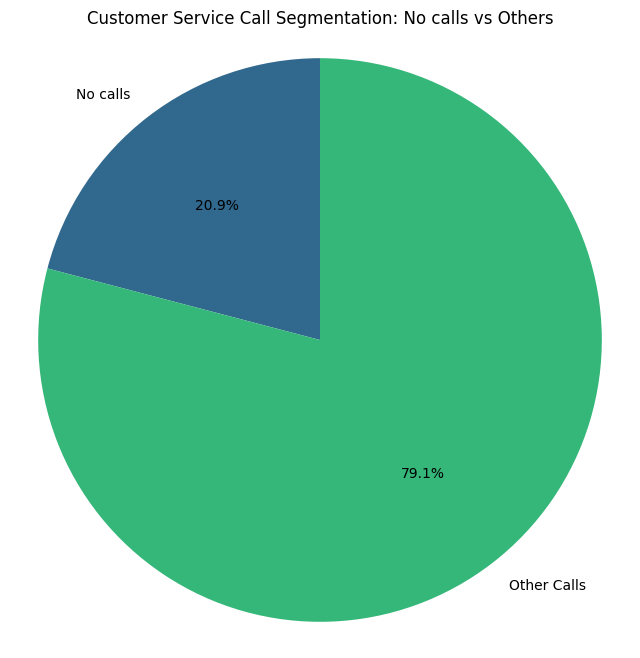

```python
segment_counts = Customer_account_segmented['Customer_segment_service'].value_counts().reindex(
    ['No calls','Low', 'Medium', 'High']
)


service_segment_counts_grouped = {
    'No calls': segment_counts.get('No calls', 0),
    'Other Calls': segment_counts.drop('No calls', errors='ignore').sum()
}

# Plot the pie chart
plt.figure(figsize=(8, 8))
plt.pie(service_segment_counts_grouped.values(), labels=service_segment_counts_grouped.keys(), autopct='%1.1f%%', startangle=90, colors=sns.color_palette('viridis', n_colors=2))
plt.title('Customer Service Call Segmentation: No calls vs Others')
plt.axis('equal')  # Ensures pie chart is circular
plt.show()
```

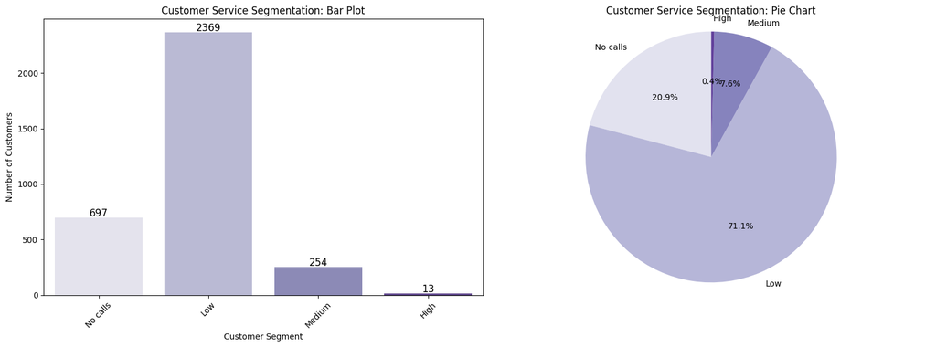

```python
#segment_counts = Customer_account_segmented['Customer_segment_service'].value_counts().reindex(
    #['No calls','Low', 'Medium', 'High']
# Bar plot
plt.figure(figsize=(16, 6))
plt.subplot(1, 2, 1)
ax = sns.barplot(x=segment_counts.index, y=segment_counts.values, palette='Purples')
for p in ax.patches:
    ax.annotate(f'{int(p.get_height())}',  # The value on the bar
                (p.get_x() + p.get_width() / 2., p.get_height()),  # Position
                ha='center', va='center', fontsize=12, color='black', xytext=(0, 5), textcoords='offset points')
plt.title('Customer Service Segmentation: Bar Plot')
plt.xlabel('Customer Segment')
plt.ylabel('Number of Customers')
plt.xticks(rotation=45)


plt.subplot(1, 2, 2)
plt.pie(segment_counts, labels=segment_counts.index, autopct='%1.1f%%', startangle=90, colors = sns.color_palette('Purples', n_colors=4))
plt.title('Customer Service Segmentation: Pie Chart')
plt.axis('equal')  # Ensures pie chart is circular
plt.tight_layout()
plt.show()
```

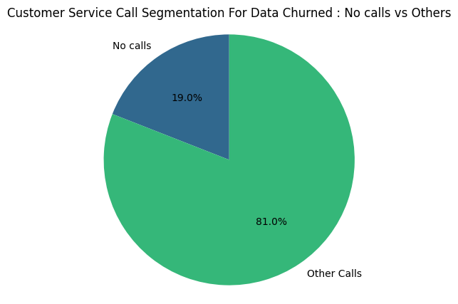

```python
# Count the values for each segment
segment_counts = data_churned['Customer_segment_service'].value_counts().reindex(
    ['No calls','Low', 'Medium', 'High']
)



service_segment_counts_grouped = {
    'No calls': segment_counts.get('No calls', 0),
    'Other Calls': segment_counts.drop('No calls', errors='ignore').sum()
}

# Plot the pie chart
plt.figure(figsize=(5, 5))
plt.pie(service_segment_counts_grouped.values(), labels=service_segment_counts_grouped.keys(), autopct='%1.1f%%', startangle=90, colors=sns.color_palette('viridis', n_colors=2))
plt.title('Customer Service Call Segmentation For Data Churned : No calls vs Others')
plt.axis('equal')  # Ensures pie chart is circular
plt.show()
```

##### Customers who made no service calls account for 19.0% of churn, while those making other calls contribute 81.0%, emphasizing the need to focus on proactive customer engagement.

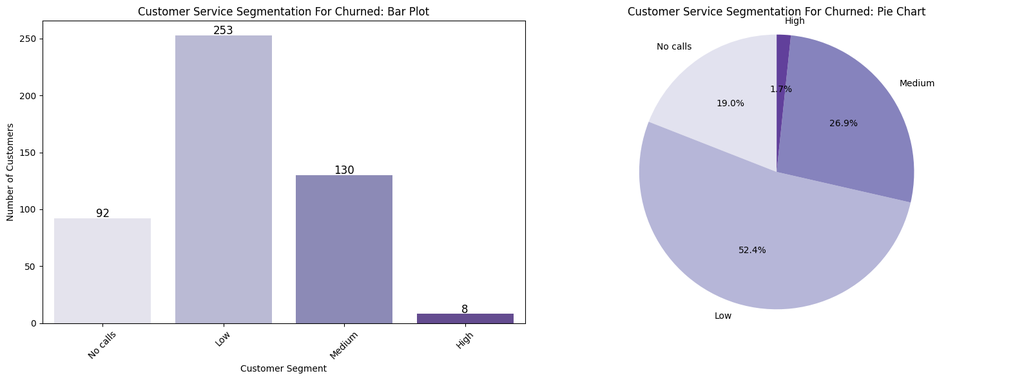

```python
#segment_counts = data_churned['Customer_segment_service'].value_counts().reindex(
   # ['No calls','Low', 'Medium', 'High']
# Bar plot
plt.figure(figsize=(16, 6))
plt.subplot(1, 2, 1)
ax = sns.barplot(x=segment_counts.index, y=segment_counts.values, palette='Purples')
for p in ax.patches:
    ax.annotate(f'{int(p.get_height())}',  # The value on the bar
                (p.get_x() + p.get_width() / 2., p.get_height()),  # Position
                ha='center', va='center', fontsize=12, color='black', xytext=(0, 5), textcoords='offset points')
plt.title('Customer Service Segmentation For Churned: Bar Plot')
plt.xlabel('Customer Segment')
plt.ylabel('Number of Customers')
plt.xticks(rotation=45)


plt.subplot(1, 2, 2)
plt.pie(segment_counts, labels=segment_counts.index, autopct='%1.1f%%', startangle=90, colors = sns.color_palette('Purples', n_colors=4))
plt.title('Customer Service Segmentation For Churned: Pie Chart')
plt.axis('equal')  # Ensures pie chart is circular
plt.tight_layout()
plt.show()
```

#### Correlatoin matrix

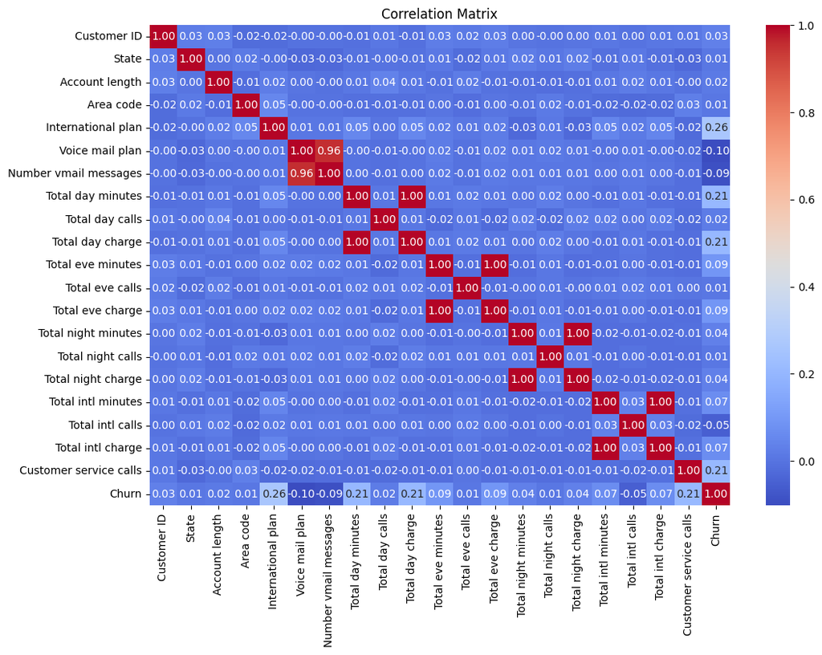

```python
correlation_matrix = data.corr()

# Plot the correlation matrix as a heatmap
plt.figure(figsize=(12, 8))
sns.heatmap(correlation_matrix, annot=True, fmt=".2f", cmap='coolwarm', cbar=True)
plt.title('Correlation Matrix')
plt.show()
```

### Churn Pridiction Analysis

```python
merged_data.columns
```

```
Index(['Customer ID', 'State', 'Account length', 'Area code',
       'International plan', 'Voice mail plan', 'Number vmail messages',
       'Total day minutes', 'Total day calls', 'Total day charge',
       'Total eve minutes', 'Total eve calls', 'Total eve charge',
       'Total night minutes', 'Total night calls', 'Total night charge',
       'Total intl minutes', 'Total intl calls', 'Total intl charge',
       'Customer service calls', 'Churn'],
      dtype='object')
```

```python
merged_data.info()
```

```
<class 'pandas.core.frame.DataFrame'>
RangeIndex: 3333 entries, 0 to 3332
Data columns (total 21 columns):
 #   Column                  Non-Null Count  Dtype
---  ------                  --------------  -----
 0   Customer ID             3333 non-null   int64
 1   State                   3333 non-null   object
 2   Account length          3333 non-null   int64
 3   Area code               3333 non-null   int64
 4   International plan      3333 non-null   object
 5   Voice mail plan         3333 non-null   object
 6   Number vmail messages   3333 non-null   int64
 7   Total day minutes       3333 non-null   float64
 8   Total day calls         3333 non-null   int64
 9   Total day charge        3333 non-null   float64
 10  Total eve minutes       3333 non-null   float64
 11  Total eve calls         3333 non-null   int64
 12  Total eve charge        3333 non-null   float64
 13  Total night minutes     3333 non-null   float64
 14  Total night calls       3333 non-null   int64
 15  Total night charge      3333 non-null   float64
 16  Total intl minutes      3333 non-null   float64
 17  Total intl calls        3333 non-null   int64
 18  Total intl charge       3333 non-null   float64
 19  Customer service calls  3333 non-null   int64
 20  Churn                   3333 non-null   bool
dtypes: bool(1), float64(8), int64(9), object(3)
memory usage: 524.2+ KB
```

```python
data = merged_data.copy()

# Encoding categorical variables
label_encoder = LabelEncoder()
data['International plan'] = label_encoder.fit_transform(data['International plan'])
data['Voice mail plan'] = label_encoder.fit_transform(data['Voice mail plan'])
data['State'] = label_encoder.fit_transform(data['State'])

# Splitting features and target variable
X = data.drop(['Churn'], axis=1)
y = data['Churn']

# Splitting data into training and testing sets
X_train, X_test, y_train, y_test = train_test_split(X, y, test_size=0.2, random_state=42, stratify=y)

# Initializing and training the Random Forest model
rf_model = RandomForestClassifier(random_state=42, n_estimators=100)
rf_model.fit(X_train, y_train)

# Making predictions
y_pred = rf_model.predict(X_test)

# Evaluating the model
print("Accuracy:", accuracy_score(y_test, y_pred))
print("Confusion Matrix:\n", confusion_matrix(y_test, y_pred))
print("Classification Report:\n", classification_report(y_test, y_pred))

# Feature importance
importances = rf_model.feature_importances_
feature_importance_df = pd.DataFrame({
    'Feature': X.columns,
    'Importance': importances
}).sort_values(by='Importance', ascending=False)

print("\nFeature Importance:")
print(feature_importance_df)
```

```
Accuracy: 0.9490254872563718
Confusion Matrix:
 [[568   2]
 [ 32  65]]
Classification Report:
               precision    recall  f1-score   support

       False       0.95      1.00      0.97       570
        True       0.97      0.67      0.79        97

    accuracy                           0.95       667
   macro avg       0.96      0.83      0.88       667
weighted avg       0.95      0.95      0.95       667


Feature Importance:
                   Feature  Importance
7        Total day minutes    0.138349
9         Total day charge    0.137784
19  Customer service calls    0.097581
4       International plan    0.081788
10       Total eve minutes    0.060751
12        Total eve charge    0.057501
17        Total intl calls    0.050410
18       Total intl charge    0.042244
16      Total intl minutes    0.038714
15      Total night charge    0.035809
13     Total night minutes    0.035543
8          Total day calls    0.031955
14       Total night calls    0.029202
2           Account length    0.029093
0              Customer ID    0.028877
6    Number vmail messages    0.026830
11         Total eve calls    0.025657
1                    State    0.025140
5          Voice mail plan    0.018530
3                Area code    0.008243
```

[figure not shown]

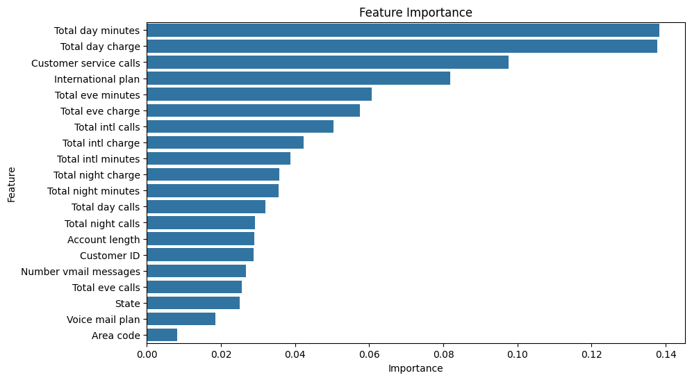

```python
#  to plotting the Confusion Matrix
cm = confusion_matrix(y_test, y_pred)

#for heat map
plt.figure(figsize=(6, 5))
sns.heatmap(cm, annot=True, fmt='d', cmap='Blues', xticklabels=['No Churn', 'Churn'], yticklabels=['No Churn', 'Churn'])
plt.title('Confusion Matrix')
plt.xlabel('Predicted')
plt.ylabel('Actual')
plt.show()

# to plot Feature Importance
importances = rf_model.feature_importances_
feature_importance_df = pd.DataFrame({
    'Feature': X.columns,
    'Importance': importances
}).sort_values(by='Importance', ascending=False)

# Creating a bar plot for feature importance
plt.figure(figsize=(10, 6))
sns.barplot(x='Importance', y='Feature', data=feature_importance_df)
plt.title('Feature Importance')
plt.show()
```

```
Accuracy: 0.8695652173913043
Confusion Matrix:
 [[558  12]
 [ 75  22]]
Classification Report:
               precision    recall  f1-score   support

       False       0.88      0.98      0.93       570
        True       0.65      0.23      0.34        97

    accuracy                           0.87       667
   macro avg       0.76      0.60      0.63       667
weighted avg       0.85      0.87      0.84       667
```

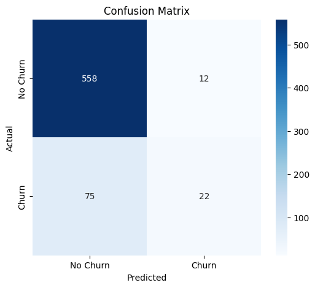

```python
# Copy the data
data = merged_data.copy()

# Encoding categorical variables
label_encoder = LabelEncoder()
data['International plan'] = label_encoder.fit_transform(data['International plan'])
data['Voice mail plan'] = label_encoder.fit_transform(data['Voice mail plan'])
data['State'] = label_encoder.fit_transform(data['State'])

# Splitting features and target variable
X = data.drop(['Churn'], axis=1)
y = data['Churn']

# Splitting data into training and testing sets
X_train, X_test, y_train, y_test = train_test_split(X, y, test_size=0.2, random_state=42, stratify=y)

# Initializing and training the Logistic Regression model
logreg_model = LogisticRegression(random_state=42, max_iter=1000)
logreg_model.fit(X_train, y_train)

# Making predictions
y_pred = logreg_model.predict(X_test)

# Evaluating the model
print("Accuracy:", accuracy_score(y_test, y_pred))
print("Confusion Matrix:\n", confusion_matrix(y_test, y_pred))
print("Classification Report:\n", classification_report(y_test, y_pred))



# Plotting the Confusion Matrix
cm = confusion_matrix(y_test, y_pred)

# Creating a heatmap for the confusion matrix
plt.figure(figsize=(6, 5))
sns.heatmap(cm, annot=True, fmt='d', cmap='Blues', xticklabels=['No Churn', 'Churn'], yticklabels=['No Churn', 'Churn'])
plt.title('Confusion Matrix')
plt.xlabel('Predicted')
plt.ylabel('Actual')
plt.show()
```

```
Accuracy: 0.9070464767616192
Confusion Matrix:
 [[540  30]
 [ 32  65]]
Classification Report:
               precision    recall  f1-score   support

       False       0.94      0.95      0.95       570
        True       0.68      0.67      0.68        97

    accuracy                           0.91       667
   macro avg       0.81      0.81      0.81       667
weighted avg       0.91      0.91      0.91       667
```

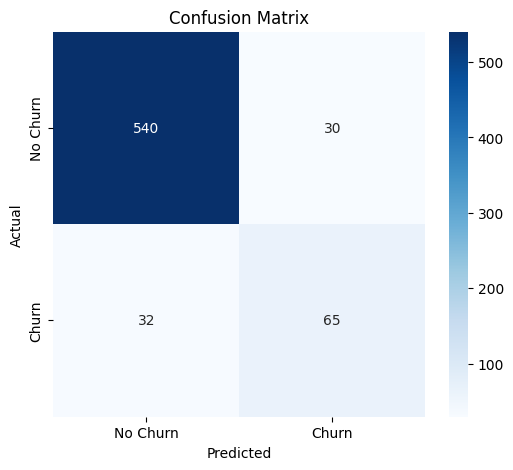

```python
data = merged_data.copy()

# Encoding categorical variables
label_encoder = LabelEncoder()
data['International plan'] = label_encoder.fit_transform(data['International plan'])
data['Voice mail plan'] = label_encoder.fit_transform(data['Voice mail plan'])
data['State'] = label_encoder.fit_transform(data['State'])

# Splitting features and target variable
X = data.drop(['Churn'], axis=1)
y = data['Churn']

# Splitting data into training and testing sets
X_train, X_test, y_train, y_test = train_test_split(X, y, test_size=0.2, random_state=42, stratify=y)

# Initializing and training the Decision Tree model
dt_model = DecisionTreeClassifier(random_state=42)
dt_model.fit(X_train, y_train)

# Making predictions
y_pred = dt_model.predict(X_test)

# Evaluating the model
print("Accuracy:", accuracy_score(y_test, y_pred))
print("Confusion Matrix:\n", confusion_matrix(y_test, y_pred))
print("Classification Report:\n", classification_report(y_test, y_pred))


# Plotting the Confusion Matrix
cm = confusion_matrix(y_test, y_pred)

# Creating a heatmap for the confusion matrix
plt.figure(figsize=(6, 5))
sns.heatmap(cm, annot=True, fmt='d', cmap='Blues', xticklabels=['No Churn', 'Churn'], yticklabels=['No Churn', 'Churn'])
plt.title('Confusion Matrix')
plt.xlabel('Predicted')
plt.ylabel('Actual')
plt.show()
```

```
Accuracy: 0.9445277361319341
Confusion Matrix:
 [[561   9]
 [ 28  69]]
Classification Report:
               precision    recall  f1-score   support

       False       0.95      0.98      0.97       570
        True       0.88      0.71      0.79        97

    accuracy                           0.94       667
   macro avg       0.92      0.85      0.88       667
weighted avg       0.94      0.94      0.94       667
```

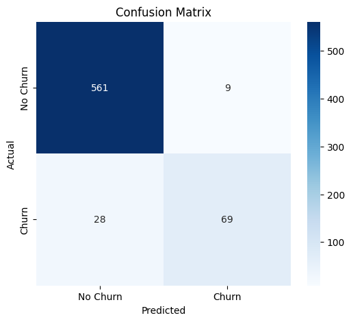

```python
data = merged_data.copy()

# Encoding categorical variables
label_encoder = LabelEncoder()
data['International plan'] = label_encoder.fit_transform(data['International plan'])
data['Voice mail plan'] = label_encoder.fit_transform(data['Voice mail plan'])
data['State'] = label_encoder.fit_transform(data['State'])

# Splitting features and target variable
X = data.drop(['Churn'], axis=1)
y = data['Churn']

# Splitting data into training and testing sets
X_train, X_test, y_train, y_test = train_test_split(X, y, test_size=0.2, random_state=42, stratify=y)

# Initializing and training the Gradient Boosting model
gb_model = GradientBoostingClassifier(random_state=42)
gb_model.fit(X_train, y_train)

# Making predictions
y_pred = gb_model.predict(X_test)

# Evaluating the model
print("Accuracy:", accuracy_score(y_test, y_pred))
print("Confusion Matrix:\n", confusion_matrix(y_test, y_pred))
print("Classification Report:\n", classification_report(y_test, y_pred))

# Plotting the Confusion Matrix
cm = confusion_matrix(y_test, y_pred)

# Creating a heatmap for the confusion matrix
plt.figure(figsize=(6, 5))
sns.heatmap(cm, annot=True, fmt='d', cmap='Blues', xticklabels=['No Churn', 'Churn'], yticklabels=['No Churn', 'Churn'])
plt.title('Confusion Matrix')
plt.xlabel('Predicted')
plt.ylabel('Actual')
plt.show()
```

```
Accuracy: 0.881559220389805
Confusion Matrix:
 [[548  22]
 [ 57  40]]
Classification Report:
               precision    recall  f1-score   support

       False       0.91      0.96      0.93       570
        True       0.65      0.41      0.50        97

    accuracy                           0.88       667
   macro avg       0.78      0.69      0.72       667
weighted avg       0.87      0.88      0.87       667
```

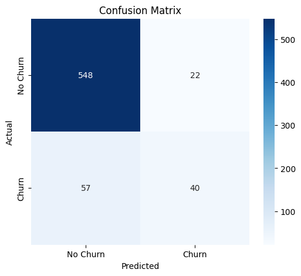

```python
data = merged_data.copy()

# Encoding categorical variables
label_encoder = LabelEncoder()
data['International plan'] = label_encoder.fit_transform(data['International plan'])
data['Voice mail plan'] = label_encoder.fit_transform(data['Voice mail plan'])
data['State'] = label_encoder.fit_transform(data['State'])

# Splitting features and target variable
X = data.drop(['Churn'], axis=1)
y = data['Churn']

# Splitting data into training and testing sets
X_train, X_test, y_train, y_test = train_test_split(X, y, test_size=0.2, random_state=42, stratify=y)

# Initializing and training the AdaBoost model
ada_model = AdaBoostClassifier(random_state=42)
ada_model.fit(X_train, y_train)

# Making predictions
y_pred = ada_model.predict(X_test)

# Evaluating the model
print("Accuracy:", accuracy_score(y_test, y_pred))
print("Confusion Matrix:\n", confusion_matrix(y_test, y_pred))
print("Classification Report:\n", classification_report(y_test, y_pred))

# Plotting the Confusion Matrix
cm = confusion_matrix(y_test, y_pred)

# Creating a heatmap for the confusion matrix
plt.figure(figsize=(6, 5))
sns.heatmap(cm, annot=True, fmt='d', cmap='Blues', xticklabels=['No Churn', 'Churn'], yticklabels=['No Churn', 'Churn'])
plt.title('Confusion Matrix')
plt.xlabel('Predicted')
plt.ylabel('Actual')
plt.show()
```

Based on the two visualizations provided (Feature Importance and Confusion Matrix), here are insights and recommendations:

### Recommendations:

1. **Focus on High-Impact Features**:
   - Prioritize strategies targeting **total day charge**, **total day minutes**, and **customer service interactions**, as these significantly impact churn.
2. **Improve Churn Identification**:
   - Enhance the model's ability to reduce false negatives, possibly by refining the decision threshold or experimenting with more advanced algorithms.
3. **Customer Service Optimization**:
   - Since customer service calls are a critical churn predictor, investigate patterns in these interactions to identify dissatisfaction and proactively address issues.
4. **Feature Optimization**:
   - Consider eliminating low-importance features like **Area code** to streamline the model and focus on more impactful variables, improving both interpretability and efficiency.